# Data Wrangling- HTS Mexico City

Orlando Sabogal-Cardona

Summer 2023

# 1 Libraries and raw data

```r
library(tidyverse)
library(magrittr)
library(sf)
```

Make sure you have the following sub-folder in your folder: https://www.dropbox.com/scl/fo/xqonwazhrwml6wp3n28md/h?dl=0&rlkey=qd0a56dfzfpqppcan1xi23597

Please note that the sub-folder is not included in the github repo due to storage constraints

```r
Zones <- st_read(
  "Mexico OD Survey/DistritosEODHogaresZMVM2017/DistritosEODHogaresZMVM2017.shp")
```

```r
Trips <- read_delim(
  "Mexico OD Survey/eod_2017_csv/tviaje_eod2017/conjunto_de_datos/tviaje.csv",
  delim = ",")
#p5_11: HomeTrip or not
#p5_13: Trip Purpose
#p5_9_1: Time the trip started
```

```r
TripsStages <- read_delim(
  "Mexico OD Survey/eod_2017_csv/ttransporte_eod2017/conjunto_de_datos/ttransporte.csv",
  delim = ",")
# id_via is the unique identifier. It is consistent with Trips
# p5_14 is the transport mode
# p5_16 is the order of the stages.
```

```r
People <- read_delim(
  "Mexico OD Survey/eod_2017_csv/tsdem_eod2017/conjunto_de_datos/tsdem.csv",
  delim = ",")
#id_soc is the unique identifier por people
```

```r
Home <- read_delim(
  "Mexico OD Survey/eod_2017_csv/thogar_eod2017/conjunto_de_datos/thogar.csv",
                   delim = ",")
```

# 2 Our Goal

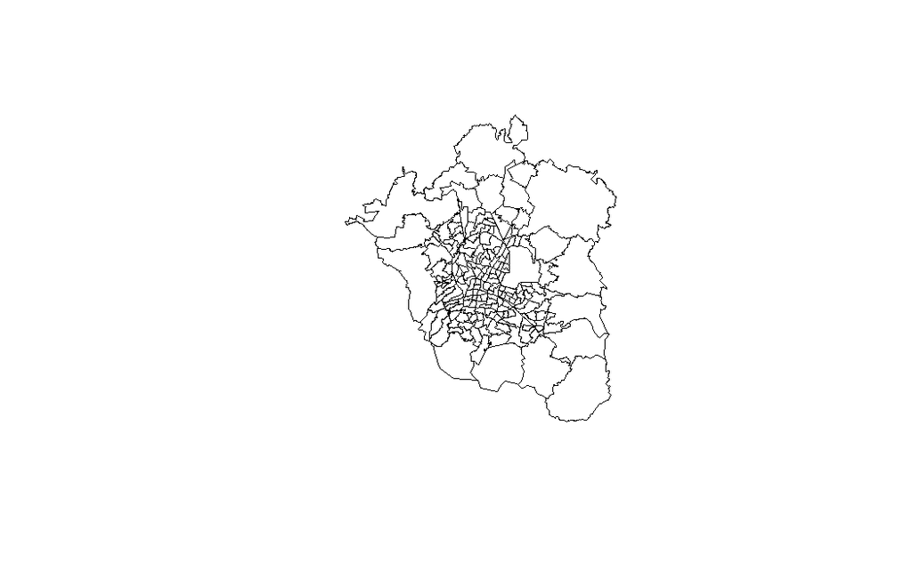

```r
plot(st_geometry(Zones))
```

```r
Zones %>% glimpse()
```

```
Rows: 194
Columns: 3
$ Distrito   <chr> "001", "002", "003", "004", "005", "006", "007", "008", "009", "0…
$ Descripcio <chr> "Centro Histórico", "Buenavista-Reforma", "Tlatelolco", "Morelos"…
$ geometry   <MULTIPOLYGON [m]> MULTIPOLYGON (((485707.7 21..., MULTIPOLYGON (((4850…
```

# 3 variables and keys

```r
dim(Trips)
```

```
[1] 531594     82
```

```r
dim(TripsStages)
```

```
[1] 890748     18
```

```r
names(Trips)
```

```
 [1] "id_via"     "id_soc"     "p5_3"       "n_via"      "p5_6"       "p5_7_6"
 [7] "p5_7_7"     "dto_origen" "p5_9_1"     "p5_9_2"     "p5_10_1"    "p5_10_2"
[13] "p5_11a"     "p5_12_6"    "p5_12_7"    "dto_dest"   "p5_13"      "p5_14_01"
[19] "p5_15_01"   "p5_14_02"   "p5_15_02"   "p5_14_03"   "p5_15_03"   "p5_14_04"
[25] "p5_15_04"   "p5_14_05"   "p5_15_05"   "p5_14_06"   "p5_15_06"   "p5_14_07"
[31] "p5_15_07"   "p5_14_08"   "p5_15_08"   "p5_14_09"   "p5_15_09"   "p5_14_10"
[37] "p5_15_10"   "p5_14_11"   "p5_15_11"   "p5_14_12"   "p5_15_12"   "p5_14_13"
[43] "p5_15_13"   "p5_14_14"   "p5_15_14"   "p5_14_15"   "p5_15_15"   "p5_14_16"
[49] "p5_15_16"   "p5_14_17"   "p5_15_17"   "p5_14_18"   "p5_15_18"   "p5_14_19"
[55] "p5_15_19"   "p5_14_20"   "p5_15_20"   "p5_18"      "p5_19"      "p5_20"
[61] "p5_21_1"    "p5_21_2"    "p5_22"      "p5_23"      "p5_24"      "p5_25"
[67] "p5_26"      "p5_27_1"    "p5_27_2"    "p5_27_3"    "p5_27_4"    "p5_27_5"
[73] "p5_27_6"    "p5_27_7"    "p5_27_8"    "estrato"    "factor"     "upm_dis"
[79] "est_dis"    "tloc"       "sexo"       "edad"
```

```r
names(TripsStages)
```

```
 [1] "id_tra"    "id_via"    "p5_3"      "n_via"     "p5_14"     "p5_16"
 [7] "p5_16_1_1" "p5_16_1_2" "p5_16_2"   "p5_17_1c"  "p5_17_2c"  "estrato"
[13] "factor"    "upm_dis"   "est_dis"   "tloc"      "sexo"      "edad"
```

Keep in mind that for the *“Trips”* object:

- **p5_11**: HomeTrip or not
- **p5_13**: Trip Purpose
- **p5_9_1**: Time the trip started
- **dto_origen**: Origin of the trip
- **dto_dest**: Destination of the trip

And keep in mind that for the *“Trips”Stages”* object: - **id_via** is the unique identifier. It is consistent with the *“Trips”* - **p5_14** is the transport mode - **p5_16** is the order of the stages.

```r
dim(People)
```

```
[1] 200117     22
```

```r
dim(Home)
```

```
[1] 56685    20
```

```r
names(People)
```

```
 [1] "id_soc"     "id_hog"     "n_ren"      "parentesco" "sexo"       "edad"
 [7] "niv"        "gra"        "p3_7"       "p3_8"       "p4_2"       "p4_3"
[13] "p5_4"       "p6_4"       "estrato"    "factor"     "upm_dis"    "est_dis"
[19] "tloc"       "distrito"   "ent"        "mun"
```

```r
names(Home)
```

```
 [1] "id_hog"   "id_viv"   "hogar"    "n_inf"    "p2_1_1"   "p2_1_2"   "p2_1_3"
 [8] "p2_2"     "p2_2b_1"  "p2_2b_2"  "p2_2b_3"  "p2_2b_4"  "estrato"  "factor"
[15] "upm_dis"  "est_dis"  "tloc"     "distrito" "ent"      "mun"
```

Keep in mind that **id_soc** is the unique identifier for every individual

# 4 Trips

```r
Trips %>% group_by(p5_13) %>% summarise(TotalTrips = n()) %>% arrange(desc(TotalTrips))
```

| p5_13 | TotalTrips |
| --- | --- |
| 01 | 248938 |
| 02 | 109187 |
| 04 | 50675 |
| 03 | 42724 |
| 05 | 40604 |
| 06 | 24891 |
| 08 | 5893 |
| 07 | 3546 |
| 10 | 3031 |
| 09 | 1811 |

[output cut: 1 more lines]

```r
class(Trips$p5_13)
```

```
[1] "character"
```

```r
PurposeNames <- data.frame(p5_13 = c(1:10,99),
                           Purpose = c("Hogar","Trabajar", "Estudiar",
                                       "Otro", "Recreacion","Otro", "Otro",
                                       "Salud", rep("Otro",3)))

Trips %<>%
  mutate(p5_13 = as.numeric(p5_13)) %>%
  left_join(PurposeNames) %>%
  select(id_via, Purpose, dto_origen, dto_dest)
```

```r
Trips
```

| id_via | Purpose | dto_origen | dto_dest |
| --- | --- | --- | --- |
| 2936 | Trabajar | 002 | 016 |
| 2937 | Hogar | 016 | 002 |
| 2938 | Recreacion | 002 | 002 |
| 2939 | Hogar | 002 | 002 |
| 2940 | Trabajar | 002 | 016 |
| 2941 | Hogar | 016 | 002 |
| 2942 | Recreacion | 002 | 002 |
| 2943 | Hogar | 002 | 002 |
| 2944 | Otro | 002 | 002 |
| 2945 | Hogar | 002 | 002 |

[output cut: 990 more lines]

## 4.2 Travel time

```r
TripsStages %>% group_by(p5_14) %>%
  summarise(TotalPerModel = n()) %>%
  arrange(desc(TotalPerModel))
```

| p5_14 | TotalPerModel |
| --- | --- |
| 14 | 390830 |
| 02 | 220483 |
| 01 | 112336 |
| 05 | 67466 |
| 04 | 26154 |
| 11 | 16185 |
| 08 | 14478 |
| 07 | 11954 |
| 06 | 6208 |
| 09 | 5752 |

[output cut: 10 more lines]

```r
class(TripsStages$p5_14)
```

```
[1] "character"
```

```r
ModesNames <- data.frame(
  p5_14 = seq(1:20),
  Modes = c("Automovil", "Colectivo_Micro", "App",
            "Taxi", "Metro", "Autobus_RTP_M1",
             "Bicicleta",  "Autobus", "Moto",  "Trolebus",
             "Metrobus_Mexibus", "TrenLigero","TrenSuburbano",
             "Caminar", "Mexicable", "Bicitaxi",  "Mototaxi",
              "TransporteEscolar", "TransporteDePersonal", "Otro"))

TripsStages %<>%
  mutate(p5_14 = as.numeric(p5_14)) %>%
  left_join(ModesNames) %>%
  select(id_via, Modes,
         TT_Hours = p5_16_1_1, TT_Minutes = p5_16_1_2) %>%
  mutate(TT_Hours = as.numeric(TT_Hours),
         TT_Minutes = as.numeric(TT_Minutes)) %>%
  filter(!TT_Hours == 99) %>% filter(!TT_Minutes == 99) %>%
  filter(TT_Hours < 4) %>%  # Remove trips lasting more than 4 hours.
  mutate(TravelTime = TT_Hours*60 + TT_Minutes)
```

## 4.3 Merge trips

```r
Trips_Final <- TripsStages %>% left_join(Trips)
```

```r
Trips_Final
```

| id_via | Modes | TT_Hours | TT_Minutes | TravelTime | Purpose | dto_origen | dto_dest |
| --- | --- | --- | --- | --- | --- | --- | --- |
| 1810 | Caminar | 0 | 5 | 5 | Hogar | 057 | 001 |
| 1811 | Colectivo_Micro | 0 | 25 | 25 | Trabajar | 001 | 064 |
| 1811 | Metro | 0 | 40 | 40 | Trabajar | 001 | 064 |
| 1811 | Caminar | 0 | 5 | 5 | Trabajar | 001 | 064 |
| 1811 | Caminar | 0 | 5 | 5 | Trabajar | 001 | 064 |
| 1812 | Colectivo_Micro | 0 | 45 | 45 | Hogar | 064 | 001 |
| 1812 | Metro | 0 | 45 | 45 | Hogar | 064 | 001 |
| 1812 | Caminar | 0 | 5 | 5 | Hogar | 064 | 001 |
| 1812 | Caminar | 0 | 5 | 5 | Hogar | 064 | 001 |
| 1813 | Metro | 0 | 10 | 10 | Otro | 001 | 001 |

[output cut: 990 more lines]

Why is this not accurate?

# 5 Data to zones

## 5.1 Trips to zones

### 5.1.1 Total trips

```r
Agg_TotalTrips <- Trips_Final %>% group_by(dto_origen) %>%
  summarise(TotalTrips = n())
```

### 5.1.2 Trips Per Mode

```r
Agg_TripsPerMode <- Trips_Final %>%
  group_by(Modes, dto_origen) %>%
  summarise(
    TripsPerMode = n(),
    TravelTime = mean(TravelTime)
  )
```

How do we fix this?

```r
Agg_TripsPerMode %>%
  pivot_wider(id_cols = dto_origen,
              names_from = Modes, names_prefix = "Trips_",
              values_from = TripsPerMode, values_fill = 0)
```

| dto_origen | Trips_App | Trips_Autobus | Trips_Autobus_RTP_M1 | Trips_Automovil | Trips_Bicicleta | Trips_Bicitaxi | Trips_Caminar | Trips_Colectivo_Micro | Trips_Metro | Trips_Metrobus_Mexibus | Trips_Mexicable | Trips_Moto | Trips_Mototaxi | Trips_Otro | Trips_Taxi | Trips_TransporteDePersonal | Trips_TransporteEscolar | Trips_TrenLigero | Trips_TrenSuburbano | Trips_Trolebus |
| --- | --- | --- | --- | --- | --- | --- | --- | --- | --- | --- | --- | --- | --- | --- | --- | --- | --- | --- | --- | --- |
| 001 | 56 | 327 | 175 | 1276 | 83 | 15 | 9264 | 4495 | 5297 | 558 | 0 | 68 | 18 | 3 | 427 | 1 | 8 | 62 | 111 | 184 |
| 002 | 68 | 209 | 101 | 1238 | 74 | 2 | 4414 | 1741 | 1725 | 727 | 1 | 64 | 10 | 3 | 205 | 5 | 9 | 12 | 115 | 25 |
| 003 | 15 | 146 | 92 | 415 | 53 | 4 | 2535 | 766 | 793 | 130 | 1 | 39 | 4 | 0 | 166 | 1 | 8 | 4 | 14 | 141 |
| 004 | 21 | 169 | 62 | 619 | 64 | 0 | 3161 | 1045 | 987 | 134 | 0 | 43 | 1 | 9 | 230 | 4 | 12 | 4 | 10 | 11 |
| 005 | 18 | 166 | 47 | 593 | 23 | 3 | 2545 | 801 | 671 | 145 | 0 | 23 | 4 | 5 | 177 | 1 | 11 | 1 | 9 | 16 |
| 006 | 32 | 95 | 63 | 760 | 59 | 2 | 3178 | 1324 | 1202 | 111 | 1 | 29 | 14 | 3 | 219 | 1 | 3 | 15 | 15 | 48 |
| 007 | 16 | 83 | 25 | 556 | 40 | 4 | 3613 | 1006 | 1399 | 135 | 0 | 39 | 7 | 0 | 156 | 1 | 2 | 7 | 21 | 97 |
| 008 | 99 | 84 | 45 | 1364 | 131 | 0 | 3745 | 1245 | 1430 | 542 | 0 | 34 | 9 | 4 | 177 | 0 | 14 | 12 | 33 | 31 |
| 009 | 51 | 50 | 24 | 1062 | 42 | 1 | 1775 | 708 | 532 | 404 | 0 | 22 | 3 | 1 | 119 | 3 | 12 | 5 | 9 | 14 |
| 010 | 45 | 30 | 9 | 673 | 27 | 0 | 1854 | 537 | 617 | 209 | 0 | 13 | 0 | 0 | 115 | 1 | 6 | 3 | 3 | 67 |

[output cut: 186 more lines]

```r
Agg_Trips_Trips <- Agg_TripsPerMode %>%
  pivot_wider(id_cols = dto_origen,
              names_from = Modes, names_prefix = "Trips_",
              values_from = TripsPerMode, values_fill = 0)

Agg_Trips_TravelTime <- Agg_TripsPerMode %>%
  pivot_wider(id_cols = dto_origen,
              names_from = Modes, names_prefix = "TravelTime_",
              values_from = TravelTime, values_fill = 0)
```

## 5.2 People to zones

### 5.2.1 Age

```r
summary(People$edad)
```

```
   Length     Class      Mode
   200117 character character
```

```r
dim(People)
```

```
[1] 200117     22
```

```r
People %>% filter(edad == "00") %>% dim()
```

```
[1] 1779   22
```

```r
People %>% filter(edad == "97") %>% dim()
```

```
[1] 65 22
```

```r
People %>% filter(edad == "99") %>% dim()
```

```
[1] 144  22
```

```r
People %<>% filter(!edad %in% c("00", "97", "99"))
dim(People)
```

```
[1] 198129     22
```

```r
People$edad = as.numeric(People$edad)
```

```r
People_TotalPeople_Age <- People %>% group_by(distrito) %>%
  summarise(TotalPeople = n(),
            Age = mean(edad, na.rm = TRUE))

People_TotalPeople_Age
```

| distrito | TotalPeople | Age |
| --- | --- | --- |
| 001 | 898 | 36.48552 |
| 002 | 858 | 38.12354 |
| 003 | 856 | 36.72547 |
| 004 | 969 | 36.85346 |
| 005 | 969 | 39.81011 |
| 006 | 844 | 39.91351 |
| 007 | 906 | 36.41280 |
| 008 | 767 | 40.57497 |
| 009 | 634 | 42.89905 |
| 010 | 726 | 41.96143 |

[output cut: 183 more lines]

### 5.2.2 Education

```r
People %>% group_by(niv) %>% summarise(Total = n())
```

| niv | Total |
| --- | --- |
| 00 | 4659 |
| 01 | 5608 |
| 02 | 44804 |
| 03 | 48747 |
| 04 | 3796 |
| 05 | 315 |
| 06 | 39194 |
| 07 | 5320 |
| 08 | 33242 |
| 09 | 2572 |

[output cut: 2 more lines]

```r
People %<>%
  mutate(EducationLevel = recode(niv,
                                 "00" = "Low",
                                 "01" = "Low",
                                 "02" = "Low",
                                 "03" = "Low",
                                 "99" = "Low", # Is this correct?
                                 "04" = "Medium",
                                 "05" = "Medium",
                                 "06" = "Medium",
                                 "07" = "Medium",
                                 "08" = "High",
                                 "09" = "High"))
```

```r
People_EducationLevel <- People %>% group_by(distrito, EducationLevel) %>%
  summarise(Total = n()) %>% drop_na() %>%
  pivot_wider(id_cols = distrito,
              names_from = EducationLevel, names_prefix = "TotalEducation_",
              values_from = Total, values_fill = 0)
People_EducationLevel
```

| distrito | TotalEducation_High | TotalEducation_Low | TotalEducation_Medium |
| --- | --- | --- | --- |
| 001 | 180 | 442 | 236 |
| 002 | 326 | 302 | 194 |
| 003 | 165 | 392 | 259 |
| 004 | 227 | 429 | 277 |
| 005 | 218 | 446 | 265 |
| 006 | 273 | 283 | 257 |
| 007 | 227 | 383 | 252 |
| 008 | 443 | 173 | 131 |
| 009 | 433 | 102 | 88 |
| 010 | 355 | 163 | 182 |

[output cut: 183 more lines]

### 5.2.3 Gender

sexo

```r
summary(People$sexo)
```

```
   Min. 1st Qu.  Median    Mean 3rd Qu.    Max.
  1.000   1.000   2.000   1.517   2.000   2.000
```

```r
summary(as.factor(People$sexo))
```

```
     1      2
 95779 102350
```

```r
People %<>% mutate(Gender = if_else(sexo == 1, "Male", "Female"))
```

```r
People_Gender <- People %>% group_by(distrito, Gender) %>%
  summarise(Total = n()) %>%
  pivot_wider(id_cols = distrito,
              names_from = Gender, names_prefix = "Total_",
              values_from = Total, values_fill = 0)
People_Gender
```

| distrito | Total_Female | Total_Male |
| --- | --- | --- |
| 001 | 475 | 423 |
| 002 | 438 | 420 |
| 003 | 440 | 416 |
| 004 | 503 | 466 |
| 005 | 513 | 456 |
| 006 | 446 | 398 |
| 007 | 470 | 436 |
| 008 | 375 | 392 |
| 009 | 355 | 279 |
| 010 | 377 | 349 |

[output cut: 183 more lines]

## 5.3 Homes to zones

p2_1_1: ¿Cuántos autos o camionetas tienen para transportarse cotidianamente? p2_1_2: ¿Cuántas motocicletas o motonetas tienen para transportarse cotidianamente? p2_1_3: ¿Cuántas bicicletas tienen para transportarse cotidianamente?

```r
Home %<>%
  select(distrito,
         Cars = p2_1_1,
         Motos = p2_1_2,
         Bicycles = p2_1_3) %>%
  mutate(
    Has_Car = if_else(Cars > 0, 1, 0),
    Has_Motos = if_else(Motos > 0, 1, 0),
    Has_Bicycles = if_else(Bicycles > 0, 1, 0))

Home
```

| distrito | Cars | Motos | Bicycles | Has_Car | Has_Motos | Has_Bicycles |
| --- | --- | --- | --- | --- | --- | --- |
| 054 | 0 | 0 | 0 | 0 | 0 | 0 |
| 054 | 1 | 0 | 0 | 1 | 0 | 0 |
| 054 | 0 | 0 | 0 | 0 | 0 | 0 |
| 054 | 0 | 0 | 0 | 0 | 0 | 0 |
| 054 | 0 | 0 | 0 | 0 | 0 | 0 |
| 054 | 0 | 0 | 0 | 0 | 0 | 0 |
| 054 | 2 | 0 | 0 | 1 | 0 | 0 |
| 054 | 1 | 0 | 0 | 1 | 0 | 0 |
| 054 | 2 | 0 | 0 | 1 | 0 | 0 |
| 054 | 2 | 0 | 0 | 1 | 0 | 0 |

[output cut: 990 more lines]

```r
Homes_TotalHomes <- Home %>%
  group_by(distrito) %>%
  summarise(Total_Homes = n())

Homes_CarOwnership <- Home %>%
  filter(Has_Car == 1) %>%
  group_by(distrito) %>%
  summarise(Homes_With_Cars = n())

Homes_MotorbikeOwnership <- Home %>%
  filter(Has_Motos == 1) %>%
  group_by(distrito) %>%
  summarise(Homes_With_Motorbikes = n())

Homes_BicycleOwnership <- Home %>%
  filter(Has_Bicycles == 1) %>%
  group_by(distrito) %>%
  summarise(Homes_With_Bicycles = n())

Homes_Mean_Veahicles <- Home %>%
  group_by(distrito) %>%
  summarise(
    Cars_mean = mean(Cars),
    Motorbikes_mean = mean(Bicycles),
    Bicycles_mean = mean(Bicycles)
  )
```